# American healt care data analysis

### Goal:

To show all I'm capable of. I do not take this project as an analysis rather as a demonstration of all my tools.

*The whole document is divided into 3 parts.*

1. **Cleaning**
- Here, I am preparing data for further analysis.
1. **Analysis and visualizations**
- In this part, I am trying to describe variables through statistics and visualize them. For example, I am using correlations, boxplots, or histograms.
1. **Hypothesis testing**
- This is the last part where I am testing some hypotheses about BMI in the US. I am using tools as t-test, ANOVA, or others.

## Imports

```python
#imports
import matplotlib.pyplot as plt
import numpy as np
import seaborn as sns
import pandas as pd
from scipy import stats
from statsmodels.stats.multicomp import pairwise_tukeyhsd
```

```python
insurance = pd.read_csv("insurance.csv")
```

```python
insurance.head()
```

|  | age | sex | bmi | children | smoker | region | charges |
| --- | --- | --- | --- | --- | --- | --- | --- |
| 0 | 19 | female | 27.900 | 0 | yes | southwest | 16884.92400 |
| 1 | 18 | male | 33.770 | 1 | no | southeast | 1725.55230 |
| 2 | 28 | male | 33.000 | 3 | no | southeast | 4449.46200 |
| 3 | 33 | male | 22.705 | 0 | no | northwest | 21984.47061 |
| 4 | 32 | male | 28.880 | 0 | no | northwest | 3866.85520 |

```python
insurance.dtypes
```

```
age           int64
sex          object
bmi         float64
children      int64
smoker       object
region       object
charges     float64
dtype: object
```

```python
insurance.describe()
```

|  | age | bmi | children | charges |
| --- | --- | --- | --- | --- |
| count | 1338.000000 | 1338.000000 | 1338.000000 | 1338.000000 |
| mean | 39.207025 | 30.663397 | 1.094918 | 13270.422265 |
| std | 14.049960 | 6.098187 | 1.205493 | 12110.011237 |
| min | 18.000000 | 15.960000 | 0.000000 | 1121.873900 |
| 25% | 27.000000 | 26.296250 | 0.000000 | 4740.287150 |
| 50% | 39.000000 | 30.400000 | 1.000000 | 9382.033000 |
| 75% | 51.000000 | 34.693750 | 2.000000 | 16639.912515 |
| max | 64.000000 | 53.130000 | 5.000000 | 63770.428010 |

## Cleaning and adjusting the table

```python
# creating categories
insurance["sex"]= pd.Categorical(insurance.sex, categories=["male","female"], ordered=True)
insurance["smoker"]= pd.Categorical(insurance.smoker, categories=["yes", "no"], ordered=True)
```

```python
# rounding
insurance.bmi= np.round(insurance.bmi, decimals=2)
insurance.charges = np.round(insurance.charges, decimals= 3)
insurance.head()
```

|  | age | sex | bmi | children | smoker | region | charges |
| --- | --- | --- | --- | --- | --- | --- | --- |
| 0 | 19 | female | 27.90 | 0 | yes | southwest | 16884.924 |
| 1 | 18 | male | 33.77 | 1 | no | southeast | 1725.552 |
| 2 | 28 | male | 33.00 | 3 | no | southeast | 4449.462 |
| 3 | 33 | male | 22.70 | 0 | no | northwest | 21984.471 |
| 4 | 32 | male | 28.88 | 0 | no | northwest | 3866.855 |

## Analysis and visualisation

### Graphical

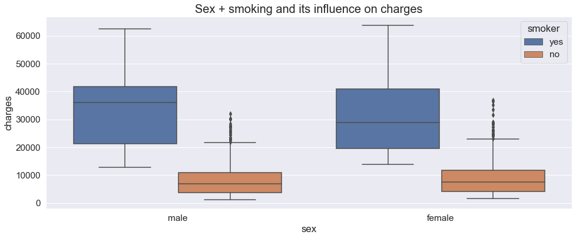

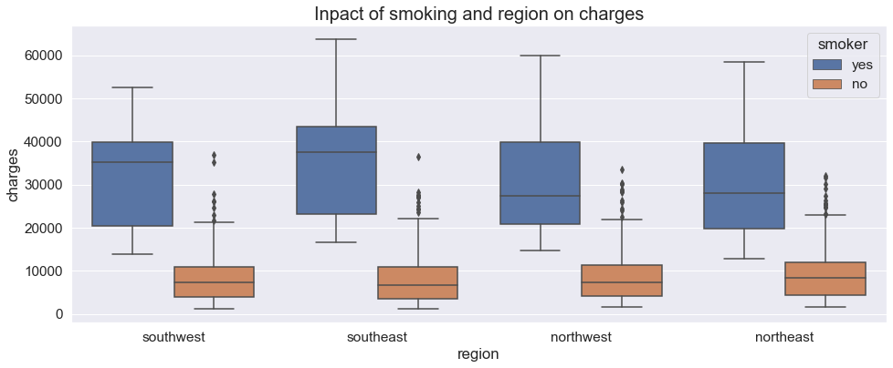

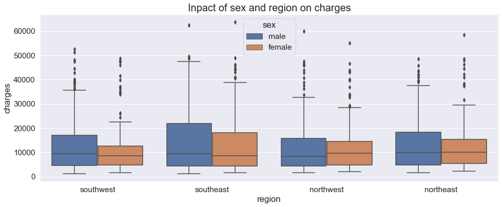

```python
# sex, smoker, region charges
plt.figure(figsize=(16, 6))
sns.set(font_scale=1.4)
sns.boxplot(x="sex", y= "charges",hue= "smoker", data= insurance)
plt.title("Sex + smoking and its influence on charges", fontsize=20)
plt.show()

plt.clf()
plt.figure(figsize=(16, 6))
sns.boxplot(x="region", y="charges", hue="smoker", data= insurance)
plt.title("Inpact of smoking and region on charges", fontsize= 20)
plt.show()

plt.clf()
plt.figure(figsize=(16, 6))
sns.boxplot(x="region", y="charges", hue="sex", data= insurance)
plt.title("Inpact of sex and region on charges", fontsize= 20)
plt.show()
```

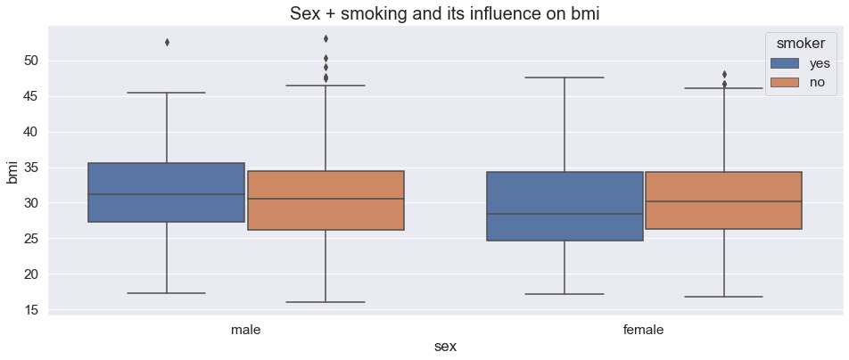

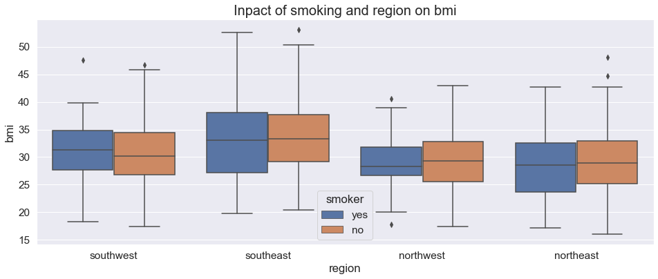

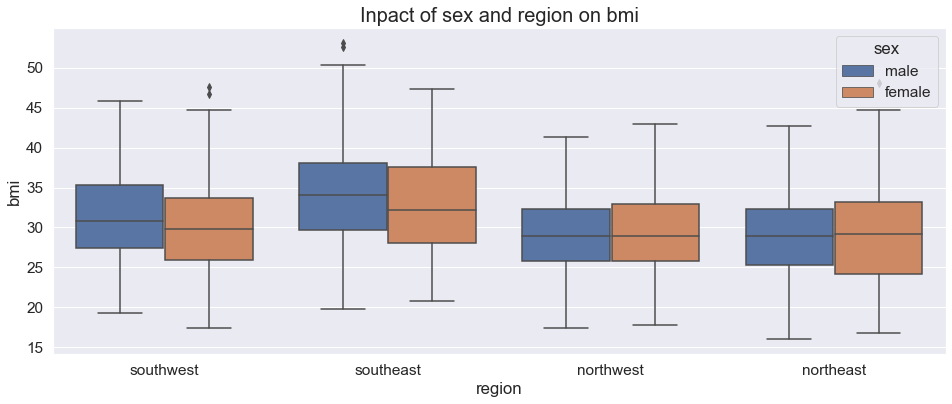

```python
# sex, smoker, region bmi
plt.figure(figsize=(16, 6))
sns.set(font_scale=1.4)
sns.boxplot(x="sex", y= "bmi",hue= "smoker", data= insurance)
plt.title("Sex + smoking and its influence on bmi", fontsize=20)
plt.show()

plt.clf()
plt.figure(figsize=(16, 6))
sns.boxplot(x="region", y="bmi", hue="smoker", data= insurance)
plt.title("Inpact of smoking and region on bmi", fontsize= 20)
plt.show()

plt.clf()
plt.figure(figsize=(16, 6))
sns.boxplot(x="region", y="bmi", hue="sex", data= insurance)
plt.title("Inpact of sex and region on bmi", fontsize= 20)
plt.show()
```

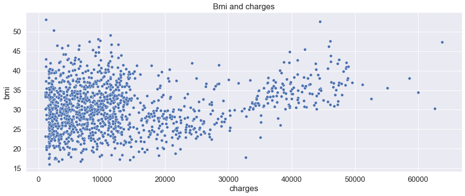

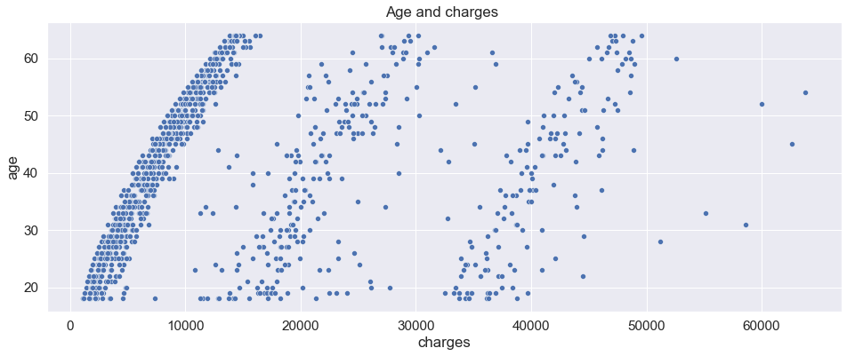

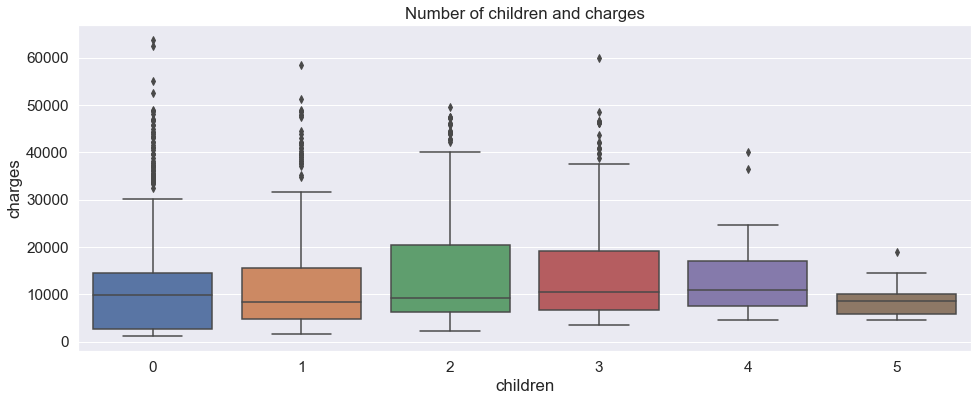

```python
# bmi, charges
plt.clf()
plt.figure(figsize=(16, 6))
sns.scatterplot(x="charges", y="bmi", data= insurance)
plt.title("Bmi and charges")
plt.show()

#age, charges
plt.clf()
plt.figure(figsize=(16, 6))
sns.scatterplot(x="charges", y="age", data= insurance)
plt.title("Age and charges ")
plt.show()

# children, charges
plt.clf()
plt.figure(figsize=(16, 6))
sns.boxplot(x="children", y="charges", data= insurance)
plt.title("Number of children and charges")
```

#### Graphical one

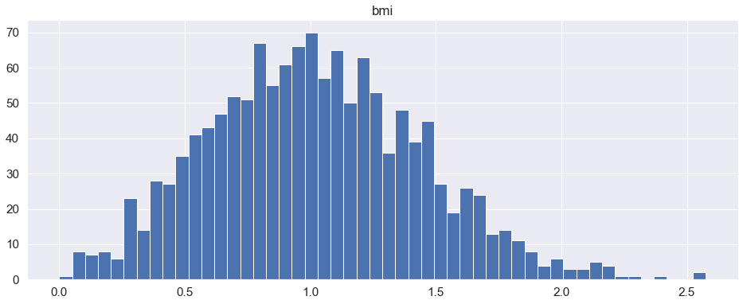

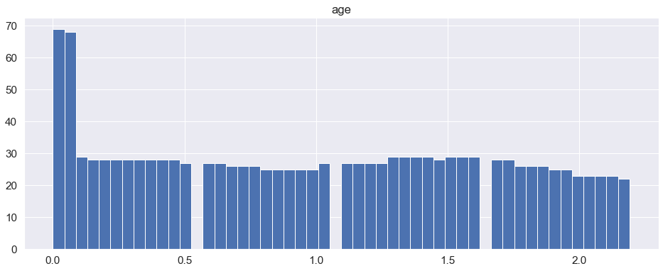

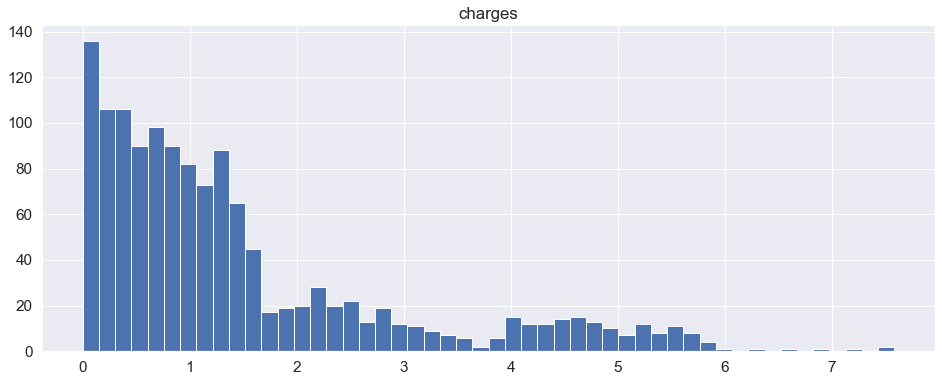

```python
def create_histogram_pandas(data, name):
    max_number = data.median()
    min_number = data.min()
    to_norm = lambda x: (x - min_number)/(max_number - min_number)
    data = data.apply(to_norm)
    plt.clf
    plt.figure(figsize=(16, 6))
    plt.hist(data, bins=50)
    plt.title(name)
    plt.show()

create_histogram_pandas(insurance.bmi, "bmi")
create_histogram_pandas(insurance.age, "age")
create_histogram_pandas(insurance.charges, "charges")
```

To make something like a summary here is a visualisation of all things together.

#### All quantitative variables - smoker and no smokers separated

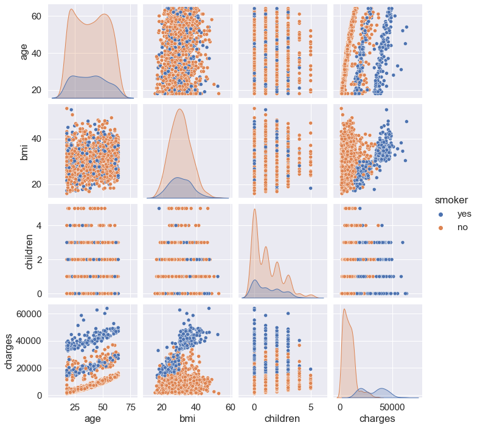

```python
plt.clf()
sns.pairplot(insurance, hue= "smoker")
plt.show()
```

#### All quantitative variables - men and women separated

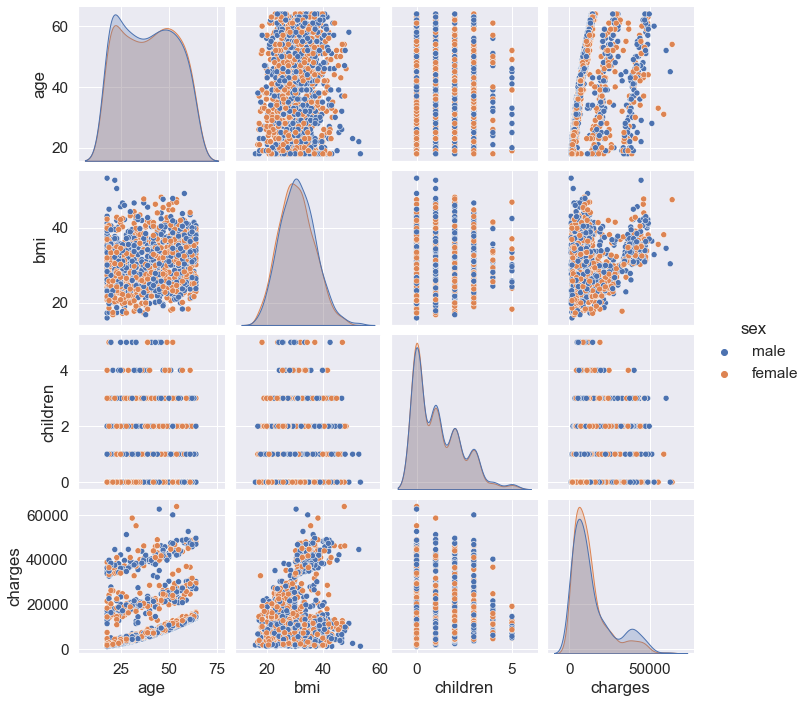

```python
plt.clf()
sns.pairplot(insurance, hue= "sex")
plt.show()
```

#### All quantitative variables - people from diffrent regions separated

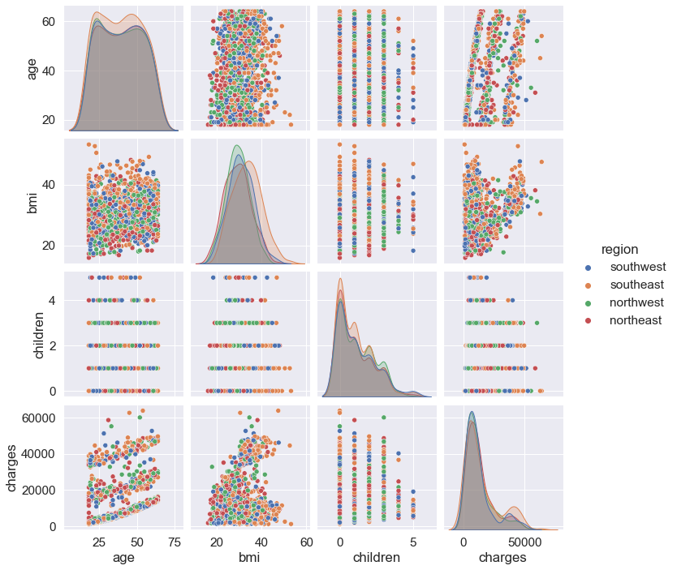

```python
plt.clf()
sns.pairplot(insurance, hue= "region")
plt.show()
```

### In numbers

```python
insurance.head()
```

|  | age | sex | bmi | children | smoker | region | charges |
| --- | --- | --- | --- | --- | --- | --- | --- |
| 0 | 19 | female | 27.90 | 0 | yes | southwest | 16884.924 |
| 1 | 18 | male | 33.77 | 1 | no | southeast | 1725.552 |
| 2 | 28 | male | 33.00 | 3 | no | southeast | 4449.462 |
| 3 | 33 | male | 22.70 | 0 | no | northwest | 21984.471 |
| 4 | 32 | male | 28.88 | 0 | no | northwest | 3866.855 |

```python
insurance.corr()
```

|  | age | bmi | children | charges |
| --- | --- | --- | --- | --- |
| age | 1.000000 | 0.109275 | 0.042469 | 0.299008 |
| bmi | 0.109275 | 1.000000 | 0.012766 | 0.198331 |
| children | 0.042469 | 0.012766 | 1.000000 | 0.067998 |
| charges | 0.299008 | 0.198331 | 0.067998 | 1.000000 |

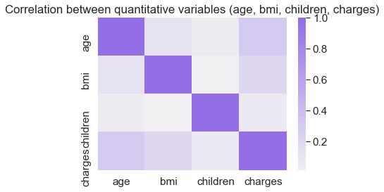

```python
plt.clf()
# Define the colormap which maps the data values to the color space defined with the diverging_palette method
colors = sns.diverging_palette(150, 275, s=80, l=55, n=9, as_cmap=True)
# Create heatmap using the .corr method on df, set colormap to cmap
sns.heatmap(insurance.corr(), center=0, cmap=colors, robust=True)
plt.title("Correlation between quantitative variables (age, bmi, children, charges)")
plt.show()
```

## Hyphothesis testing

```python
#used DIY functions
def two_samples_validate(sample1, sample2, threshold):
    pval = stats.ttest_ind(sample1, sample2)[1]
    if threshold > 0.1:
        print("Are you sure to use threshold bigger then 0.1?")
    if pval > threshold:
        print("P-value isn't significant.")
        return pval
    elif pval < threshold:
        print("P-value is significant.")
        return pval
    else:
        print("Validation Error!")
def validate(pval, threshold):
    if threshold > 0.1:
        print("Are you sure to use threshold bigger then 0.1?")
    if pval > threshold:
        print("P-value isn't significant.")
        return False
    elif pval < threshold:
        print("P-value is significant.")
        return True
    else:
        print("Validation Error!")
```

### Is any categorical variable effecting bmi?

#### BMI and smokers

**Null:** There is no difference in average BMI between smokers and not smokers.

```python
smokers = insurance[insurance.smoker == "yes"].bmi
no_smokers = insurance[insurance.smoker == "no"].bmi
smokers_bmi_pval = two_samples_validate(smokers, no_smokers, 0.05)
```

```
P-value isn't significant.
```

There is no difference in average BMI between smokers and not smokers

#### BMI and region

**Null:** There is no difference in average BMI between regions.

```python
#separating bmi according to regions
southwest = insurance[insurance.region == "southwest"].bmi
southeast = insurance[insurance.region == "southeast"].bmi
northeast = insurance[insurance.region == "northeast"].bmi
northwest = insurance[insurance.region == "northwest"].bmi

#ANOVA
pval_anova = stats.f_oneway(southwest, southeast, northeast, northwest)[1]
anova_significance = validate(pval_anova, 0.05)
print("Not all region has same bmi, so it is time dig deeper.")

#Tukey test
tukey_results = pairwise_tukeyhsd(insurance.bmi, insurance.region)
print(tukey_results)
```

```
P-value is significant.
Not all region has same bmi, so it is time dig deeper.
   Multiple Comparison of Means - Tukey HSD, FWER=0.05
==========================================================
  group1    group2  meandiff p-adj   lower   upper  reject
----------------------------------------------------------
northeast northwest   0.0269    0.9 -1.1546  1.2084  False
northeast southeast   4.1824  0.001   3.033  5.3319   True
northeast southwest   1.4231 0.0107  0.2416  2.6045   True
northwest southeast   4.1555  0.001   3.007   5.304   True
northwest southwest   1.3962 0.0128  0.2156  2.5767   True
southeast southwest  -2.7594  0.001 -3.9079 -1.6109   True
----------------------------------------------------------
```

There is significant difference in bmi between regions according to p-values. We can find significant difference between all regions expect of norhteast and northwest.

**Null:** There is no difference in BMI bewteen South and North of USA.

```python
#separating according to geopgraphical locations
south = pd.concat([southwest, southeast])
north = pd.concat([northeast, northwest])


geograph_bmi = two_samples_validate(south, north, 0.05)
print(geograph_bmi)
```

```
P-value is significant.
2.9403158555856164e-18
```

There is significant diffrence in bmi between North and South of USA.

#### Bmi and gender

**Null:** There is no difference in precetage of obese people (BMI > 30) between man and women

```python
#separating men and women
men = insurance[insurance.sex == "male"]
women = insurance[insurance.sex == "female"]
```

```python
# before I can say if the precentage is different. I need to find the precentages.
def find_obese(data, level):
    num_obese = 0
    for i in range(len(data)):
        if data.iloc[i].bmi > level:
            num_obese += 1
    prec_obese = num_obese/ len(data) * 100
    return prec_obese
```

```python
prec_obese_men = find_obese(men, 30)
prec_obese_women = find_obese(women, 30)
print("In data we have {} % obese men and {} % obese women.".format(np.round(prec_obese_men, decimals=2), np.round(prec_obese_women, decimals= 2)))
```

```
In data we have 54.88 % obese men and 50.45 % obese women.
```

```python
# no is time to test if we are able to get % of obese men with women and vice versa.
# prec-men + women data
p_value_women = stats.binom_test(prec_obese_women/100, len(women), prec_obese_men/100, alternative= "greater")
significance_women= validate(p_value_women, 0.05)

# prec-women + men data
p_value_men = stats.binom_test(prec_obese_men/100, len(men), prec_obese_women/100)
significance_men= validate(p_value_men, 0.05)

print("P-value women: {}".format(p_value_women))
print("P_value men: {}".format(p_value_men))
```

```
P-value isn't significant.
P-value is significant.
P-value women: 1.0
P_value men: 6.772008395660982e-207
```

It seems like the precentage of obese men can't be easier reached. To confirm this idea I will perform two sample test to say if avarage BMI between men is different to avearage between women.

```python
two_samples_validate(men.bmi, women.bmi, 0.05)
```

```
P-value isn't significant.
```

```
0.08993627112442361
```

It seems like that although averages isn't different, the prec of obese is not same betweem women and men.